# Assignment 8 Extended

The question is if I can make a model that can take in an audio sample of a song and predict its genre. The dataset I will be using is the GATZN dataset and it contains 1000 samples of music across 10 genres. [here](https://www.kaggle.com/datasets/andradaolteanu/gtzan-dataset-music-genre-classification)

```python
import pandas as pd
from sklearn.model_selection import train_test_split
from sklearn.cluster import KMeans
from sklearn.metrics import accuracy_score, classification_report
import os
import csv
#import essentia.standard as es
import numpy as np
from sklearn.preprocessing import LabelEncoder
from sklearn.model_selection import GridSearchCV
from sklearn import svm
from sklearn.ensemble import RandomForestClassifier
import seaborn as sns
from sklearn import metrics
```

## How can I represent an audio file in another way so that a classification model can better understand it?

```python
music_df = pd.read_csv('Music_Features.csv')
```

## How can the data be better represented?

The data contains categorical data so I decided to encode the key and key scale column so that each unique character is assigned with a number.

```python
key_encoder = LabelEncoder()
music_df['key_encoded'] = key_encoder.fit_transform(music_df['key'])
music_df['key_scale_encoded'] = key_encoder.fit_transform(music_df['key_scale'])
```

## Summary Statistics

Looking at the summary statistics there are 999 entries because 1 entry had problems when extracting features. The other features seem to have a wide variability however one possible issue is that some feature values are larger than others which could have some negative effects on models that rely on distance.

```python
music_df.describe()
```

|  | duration | tempo | danceability | key_strength | spectral_centroid | loudness | zerocrossingrate | key_encoded | key_scale_encoded |
| --- | --- | --- | --- | --- | --- | --- | --- | --- | --- |
| count | 999.000000 | 999.000000 | 999.000000 | 999.000000 | 999.000000 | 999.000000 | 999.000000 | 999.000000 | 999.000000 |
| mean | 30.024048 | 117.598813 | 2.628735 | 0.833737 | 1318.279666 | 960.442837 | 0.053997 | 5.363363 | 0.421421 |
| std | 0.080951 | 23.423690 | 1.073069 | 0.114710 | 489.616029 | 606.285905 | 0.022032 | 3.569676 | 0.494034 |
| min | 29.931950 | 62.836998 | 0.231736 | 0.335634 | 385.783508 | 18.161877 | 0.010927 | 0.000000 | 0.000000 |
| 25% | 30.000159 | 99.094498 | 1.895153 | 0.807867 | 949.494934 | 540.237854 | 0.036170 | 3.000000 | 0.000000 |
| 50% | 30.013311 | 115.712074 | 2.970703 | 0.867044 | 1275.695557 | 823.537170 | 0.052043 | 5.000000 | 0.000000 |
| 75% | 30.013311 | 132.181740 | 3.472937 | 0.905937 | 1636.648376 | 1338.728943 | 0.069045 | 9.000000 | 1.000000 |
| max | 30.648866 | 198.768097 | 4.438178 | 0.984608 | 5250.284180 | 3783.610840 | 0.143342 | 11.000000 | 1.000000 |

## Split Data

The data is then split into two groups the x and y. The song name, duration, key, and key scale were dropped because they were unnecessary. The duration is 30 seconds for every sample and the key and key scale were replaced by the encoded versions

```python
X = music_df.drop(['song_name', 'label','duration','key','key_scale'], axis=1)
y = music_df['label']
X_train, X_test, y_train, y_test = train_test_split(X, y, test_size=0.2, random_state=1239)
```

## How well will an svm model work at classifying the samples?

The model had an accuracy of 0.435 which is not bad. Looking at the classification we can see that it performed quite well with classical music at 0.81. Most of the genres were in the middle while rock was the most neglected with only 10 percent being guessed correctly. These low scores could be a result of a potential overlap between these features and other genres

```python
svm_clf = svm.SVC(kernel='linear')
svm_clf.fit(X_train, y_train)
y_pred = svm_clf.predict(X_test)
print(accuracy_score(y_test, y_pred))
print(classification_report(y_test, y_pred))
```

```
0.435
              precision    recall  f1-score   support

       blues       0.39      0.30      0.34        23
   classical       0.81      0.85      0.83        20
     country       0.45      0.53      0.49        19
       disco       0.35      0.38      0.36        24
      hiphop       0.43      0.50      0.47        20
        jazz       0.39      0.39      0.39        18
       metal       0.42      0.42      0.42        19
         pop       0.48      0.48      0.48        23
      reggae       0.35      0.44      0.39        16
        rock       0.10      0.06      0.07        18

    accuracy                           0.43       200
   macro avg       0.42      0.43      0.42       200
weighted avg       0.42      0.43      0.43       200
```

## What are the most important features when classifying a song genre?

After plotting the coefficients I found that the most important is danceability which kind of makes sense as classical had the highest accuracy and it's not music you dance to. What this also showed was that really none of the other features had a significant impact other than key_scale and maybe key strength and possibly the model is not able to capture a strong enough relationship between genres. This could be a result of a couple of things maybe I should try another model or maybe the features I have are not good enough.

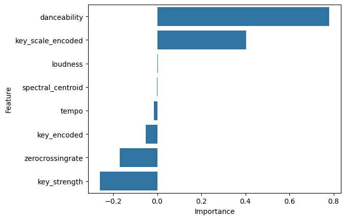

```python
importance_df = pd.DataFrame({'Feature': X.columns, 'Importance': svm_clf.coef_[0]})
importance_df = importance_df.sort_values(by='Importance', ascending=False)
sns.barplot(x='Importance', y='Feature', data=importance_df)
```

## Will a random forest model work better?

After using svm I decided to use a random forest classifier as it might be better at capturing more complex relationships. I decided to utilize grid search to test different parameters to see which works best in general and it also utilizes cross-validation which is especially good for this model as it is prone to overfitting.

```python
param_grid = {'n_estimators': [50, 100, 150, 200],'max_depth': [10, 20, 30],'min_samples_split': [2, 5],}
rf_clf = RandomForestClassifier()
rf_opt = GridSearchCV(rf_clf,param_grid,cv=5)
rf_opt.fit(X_train, y_train)
rf_df = pd.DataFrame(rf_opt.cv_results_)
```

## Which forest performed best?

After training the data and utilizing grid search the parameters that performed the best were the one with the max depth at 10, min samples split at 5, and the number of estimators at 150. That configuration had a mean score of 0.49 which is decent and had a variation of 0.04. The top 5 performed very similarly to each other and were all within 0.1 and with a variance of 0.04, there wasn't a clear victory here. In the future perhaps I could utilize a more diverse set of parameters top get more varied results or I could find what model trains the fastest which could be useful if I ever plan to scale the training set as the performance did not vary by much between configurations.

```python
rf_df.sort_values(by='rank_test_score',ascending=True).head(5)
```

|  | mean_fit_time | std_fit_time | mean_score_time | std_score_time | param_max_depth | param_min_samples_split | param_n_estimators | params | split0_test_score | split1_test_score | split2_test_score | split3_test_score | split4_test_score | mean_test_score | std_test_score | rank_test_score |
| --- | --- | --- | --- | --- | --- | --- | --- | --- | --- | --- | --- | --- | --- | --- | --- | --- |
| 6 | 0.228350 | 0.005114 | 0.010173 | 0.000349 | 10 | 5 | 150 | {'max_depth': 10, 'min_samples_split': 5, 'n_e... | 0.51250 | 0.45625 | 0.50625 | 0.56250 | 0.446541 | 0.496808 | 0.042006 | 1 |
| 3 | 0.303391 | 0.001442 | 0.013339 | 0.000225 | 10 | 2 | 200 | {'max_depth': 10, 'min_samples_split': 2, 'n_e... | 0.50625 | 0.43750 | 0.51250 | 0.54375 | 0.452830 | 0.490566 | 0.039486 | 2 |
| 19 | 0.328607 | 0.005534 | 0.013764 | 0.000121 | 30 | 2 | 200 | {'max_depth': 30, 'min_samples_split': 2, 'n_e... | 0.51250 | 0.44375 | 0.48750 | 0.53750 | 0.465409 | 0.489332 | 0.033197 | 3 |
| 7 | 0.298146 | 0.002028 | 0.012698 | 0.000228 | 10 | 5 | 200 | {'max_depth': 10, 'min_samples_split': 5, 'n_e... | 0.47500 | 0.45625 | 0.52500 | 0.53125 | 0.446541 | 0.486808 | 0.035010 | 4 |
| 18 | 0.250756 | 0.004774 | 0.010788 | 0.000129 | 30 | 2 | 150 | {'max_depth': 30, 'min_samples_split': 2, 'n_e... | 0.50625 | 0.46250 | 0.51250 | 0.51250 | 0.433962 | 0.485542 | 0.031855 | 5 |

## How well does the random forest model capture the data?

The best configuration was used to evaluate its performance. The model performed better than the last model with an accuracy of 56 percent. Looking at the breakdowns between genres the values now are a lot closer and higher across the board. Classical accuracy decreased but the lowest for both models rock increased in this model to 28 percent which is much better. This leads me to believe that the features of this dataset might have a mild overlap causing confusion between genres.

```python
y_pred = rf_opt.best_estimator_.predict(X_test)
print(accuracy_score(y_test, y_pred))
print(classification_report(y_test, y_pred))
```

```
0.56
              precision    recall  f1-score   support

       blues       0.60      0.39      0.47        23
   classical       0.71      0.75      0.73        20
     country       0.58      0.58      0.58        19
       disco       0.50      0.62      0.56        24
      hiphop       0.62      0.75      0.68        20
        jazz       0.56      0.50      0.53        18
       metal       0.62      0.53      0.57        19
         pop       0.57      0.52      0.55        23
      reggae       0.55      0.69      0.61        16
        rock       0.28      0.28      0.28        18

    accuracy                           0.56       200
   macro avg       0.56      0.56      0.56       200
weighted avg       0.56      0.56      0.56       200
```

## What features were most important in predicting music genres in a random forest?

After plotting it seems that more features are utilized by the decision tree which is why there were probably higher scores across the genres. This makes sense though as I don't believe that the SVM was the best model due to the unclear boundary between features especially due to utilizing a linear decision boundary. The most important features were loudness followed by danceability and the zero crossing rate(zcr). These all seem to be important features as the zcr is important when identifying more smoother or not sounds so heavy metal and classical would be opposites. Overall the random forest seemed to capture more relationships than expected.

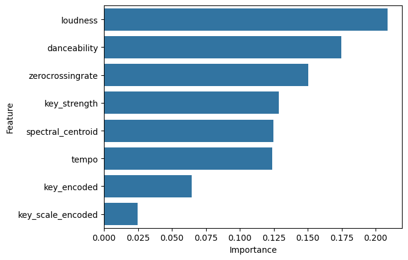

```python
importance_df = pd.DataFrame({'Feature': X.columns, 'Importance': rf_opt.best_estimator_.feature_importances_})
importance_df = importance_df.sort_values(by='Importance', ascending=False)
sns.barplot(x='Importance', y='Feature', data=importance_df)
```

## Could clustering work to identify the different genres?

For fun to test how effect clustering will perform at identifying the genres I am using Kmeans and telling it that there will be 10 clusters. Although clustering probably won't be useful for my initial question it could be useful in identifying similar groups(features) of music which could be great for recommendation systems.

```python
kmeans = KMeans(n_clusters=10)
clusters = kmeans.fit_predict(X)
```

## How well did clustering perform?

The model performed at a lower medium level. The silhouette score was 34 percent which shows there was a moderate separation between the 10 groups. I also was able to test how well the correct labels for the genres fell on the clustering and it wasn't too good at 0.16 which means there is a weak association between the true labels and the predicted clusters. However, this was expected and was not to be taken seriously as for one these clustering did not necessarily identify 10 groups of genres as they were only provided features. Perhaps the model found 10 groups of similar music with the features given. This highlights the usefulness of clustering with the intention of them being useful when you need to group similar things. In this case, it could be useful for music when you want to recommend similar songs without just using the genres because by using clustering and various features from songs you could find hidden subgroups within a genre or a bridge between genres.

```python
metrics.silhouette_score(X, clusters),metrics.adjusted_mutual_info_score(music_df['label'], clusters)
```

```
(0.3465251539640767, 0.16414420047645578)
```